# Homework Vignette

20081

2020-12-17

# Homework 0

## Question

The Fisher `iris` dataset gives four measurements on observations from three species of iris, whose names are setosa, versicolor and virginica. We will produce three examples based on `iris` dataset. The first one contains a combinatorial plot describing the distribution of the two features, sepal length and sepal width. The second example shows a table summarizing `iris` dataset. The third example illustrates a machine learning algorithm for species classification, including the theory and classification result.

## Answer

### Example 1

The combinatorial plot contains two univariate histograms, describing the distribution of variable sepal length and sepal width. The scatterplot is a bivariate plot. From the scatterplot, it seems that we can seperate these three flowers according to features sepal width and sepal length. This will be demonstrated in `Example 3`.

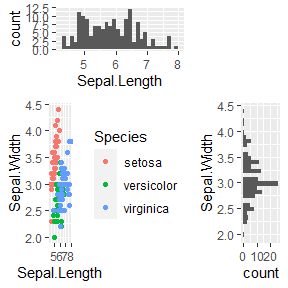

```r
library(grid)
library(ggplot2)
# Show bivariate scatter plot and univariate histogram
p.scatter <- ggplot(iris) + geom_point(aes(x=Sepal.Length, y=Sepal.Width, color=Species))
p.hist.len <- ggplot(iris) + geom_histogram(aes(x=Sepal.Length))
p.hist.wid <- ggplot(iris) + geom_histogram(aes(x=Sepal.Width)) + coord_flip()
grid.newpage()
pushViewport(viewport(layout = grid.layout(3, 3)))
print(p.scatter, vp=viewport(layout.pos.row=2:3, layout.pos.col=1:2))
print(p.hist.len, vp=viewport(layout.pos.row=1, layout.pos.col=1:2))
print(p.hist.wid, vp=viewport(layout.pos.row=2:3, layout.pos.col=3))
```

### Example 2

This table shows the first five rows of `iris` dataset.

```r
knitr::kable(head(iris, n=5))
```

| Sepal.Length | Sepal.Width | Petal.Length | Petal.Width | Species |
| --- | --- | --- | --- | --- |
| 5.1 | 3.5 | 1.4 | 0.2 | setosa |
| 4.9 | 3.0 | 1.4 | 0.2 | setosa |
| 4.7 | 3.2 | 1.3 | 0.2 | setosa |
| 4.6 | 3.1 | 1.5 | 0.2 | setosa |
| 5.0 | 3.6 | 1.4 | 0.2 | setosa |

The following table gives a summary of `iris` dataset.

```r
knitr::kable(summary(iris))
```

|  | Sepal.Length | Sepal.Width | Petal.Length | Petal.Width | Species |
| --- | --- | --- | --- | --- | --- |
|  | Min. :4.300 | Min. :2.000 | Min. :1.000 | Min. :0.100 | setosa :50 |
|  | 1st Qu.:5.100 | 1st Qu.:2.800 | 1st Qu.:1.600 | 1st Qu.:0.300 | versicolor:50 |
|  | Median :5.800 | Median :3.000 | Median :4.350 | Median :1.300 | virginica :50 |
|  | Mean :5.843 | Mean :3.057 | Mean :3.758 | Mean :1.199 | NA |
|  | 3rd Qu.:6.400 | 3rd Qu.:3.300 | 3rd Qu.:5.100 | 3rd Qu.:1.800 | NA |
|  | Max. :7.900 | Max. :4.400 | Max. :6.900 | Max. :2.500 | NA |

### Example 3

Here we illustrate the theory of Naive Bayes[1]: Suppose that we wish to classify an observation into one of $K$ classes, where $K \geq 2$. In other words, the qualitative response variable $Y$ can take on $K$ possible distinct and unordered values. Let $\pi_k$ represent the overall or prior prior probability that a randomly chosen observation comes from the $k$th class; this is the probability that a given observation is associated with the $k$th category of the response variable $Y$ . Let $f_k(x) \equiv \text{Pr}(X=x | Y=k)$ denote the density function of $X$ for an observation that comes from the $k$th class. In other words, $f_k(x)$ is relatively large if there is a high probability that function an observation in the kth class has $X \approx x$, and $f_k(x)$ is small if it is very unlikely that an observation in the $k$th class has $X \approx x$. Then Bayes’ theorem states that
$$\text{Pr}(Y=k | X=x) = \frac{\pi_k f_k(x)}{ \sum_{l=1}^{K} \pi_l f_l(x)}.$$

We will use Naive Bayes algorithm on `iris` dataset. The accuracy evaluation will be based on five-fold cross validation. The overall accuracy score is calculated by
$$\text{accuracy} = \frac{1}{5} \sum_{k=1}^{5} \text{accuracy}_{k}^{CV}.$$

```r
library(caret)  #`library(caret)` for cross validation
library(e1071)  # `library(e1071)` for Naive Bayes
set.seed(922)
trainIndex <- createDataPartition(iris$Species,p=0.8,list=F,times=5)


accuracy <- rep(0, 5)# A numeric vector for restoring validated accuracy
for (fold in 1:5){
  train.idx <- trainIndex[,fold]
  nb <- naiveBayes(Species ~., data=iris)
  pred <- predict(nb, iris[-train.idx, 1:4], type="class")  # prediction on validation dataset
  accuracy[fold] <- confusionMatrix(iris[-train.idx, 5], pred)[["overall"]][1]
}

cat("The mean accuracy of five-fold cross validation is", mean(accuracy))
```

```
#> The mean accuracy of five-fold cross validation is 0.9866667
```

## Reference

[1] James G , Witten D , Hastie T , et al. An Introduction to Statistical Learning[M]. Springer New York, 2013.

# Homework 1

## 3.3

The Pareto(a, b) distribution has cdf
$$F(x) = 1-(\frac{b}{x})^a, x\geq b>0, a>0.$$
Derive the probability inverse transformation $F^{-1}(U)$ and use the inverse transform method to simulate a random sample from the Pareto(2, 2) distribution. Graph the density histogram of the sample with the Pareto(2, 2) density superimposed for comparison.

$\textbf{Solution:}$

Let $y=1-(\frac{b}{x})^a$, and express $x$ as a function of $y$,
$$(\frac{b}{x})^a=1-y$$
$$\begin{aligned}
& \Leftrightarrow \log(\frac{b}{x}) = \frac{1}{a} \log(1-y) \\
& \Leftrightarrow x = \exp\left\{ \log b - \frac{\log(1-y)}{a}\right\} \\
& \Leftrightarrow x=\frac{b}{\exp\left( \frac{\log(1-y)}{a}\right)} \\
& \Leftrightarrow x = b(1-y)^{-1/a}.
\end{aligned}$$

Then $F^{-1}(U)=b(1-U)^{-1/a}.$

The probability density function is $f(x)=F'(x)=ab^ax^{-(a+1)}.$

$\textbf{Code:}$

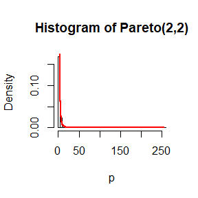

```r
generate.pareto <- function(n, a, b){
  U <- runif(n)
  P <- b * (1 - U)^(-1 / a)
  return (P)
}

set.seed(929)
a <- b <- 2
p <- generate.pareto(1e4, a, b)

hist(p, prob=TRUE, breaks=50, main="Histogram of Pareto(2,2)")
y <- sort(p)
fy <- a * b^a * y^(-(a + 1))
lines(y, fy, col="red", lty=1, lwd=2)
```

The figure below shows the histogram density estimate and the true density function(in red line).

## 3.9

The rescaled Epanechnikov kernel is a symmetric density function
$$f_e(x)=\frac{3}{4}(1-x^2), |x| \leq 1.$$
Devroye and Gyorfi give the following algorithm for simulation from this distribution. Generate iid $U_1, U_2, U_3 \sim Uniform(-1, 1).$ If $|U_3| \geq |U_2|$ and $|U_3| \geq |U_1|$, deliver $U_2$; otherwise deliver $U_3$. Write a function to generate random variates from $f_e$, and construct the histogram density estimate of a large simulated random sample.

$\textbf{Solution:}$

$\textbf{Code:}$

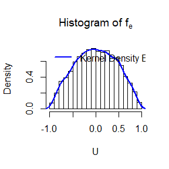

```r
generate.fe <- function(n){
  U1 <- runif(n, -1, 1)
  U2 <- runif(n, -1, 1)
  U3 <- runif(n, -1, 1)

  U <- ifelse((abs(U3) >= abs(U2) & abs(U3) >= abs(U1)), U2, U3)
  return (U)
}

set.seed(929)
U <- generate.fe(1e4)
hist(U, breaks = 20, prob=TRUE, main=expression(paste("Histogram of ", f[e])))
lines(density(U), lty=1, lwd=2, col="blue")
legend("topleft", "Kernel Density Estimate", lwd=2, col="blue", lty=1, bty="n")
```

The figure below shows the histogram density estimate and the kernel density function(in blue line).

## 3.10

Prove that the algorithm given in Exercise 3.9 generates variates from the density $f_e$.

$\textbf{Proof:}$

From the fact that $U \sim Uniform(-1,1), |U| \sim U(0,1)$, we can restate the algorithm as follows:

Generate iid $V_1, V_2, V_3 \sim Uniform(0, 1)$. If $V_3 = \max(V_1, V_2, V_3)$, then $V=V_2$, otherwise $V=V_3$. We can see that $V$ is either the first or the second ordered statistic of $V_1, V_2, V_3$. Then deliver $Y=\pm V$ with probability 1/2, 1/2 finally.

Note that the distribution function of the $k^{th}$ ordered statistc when $n=3$ is given by
$$G_k(y_k) = P(V_{(k)} \leq y_k) = \sum_{j=k}^{3} C_{3}^{j} [F(y_k)]^j [1-F(y_k)]^{3-j},$$
where $F(y_k)=y_k$ is the cdf of $Uniform(0,1)$.

The distribution function of $V$ is
$$\begin{aligned}
G(v) &= \frac12G_1(v) + \frac12G_2(v) \\
&= \frac12[(1-(1-v)^3) + (3v^2(1-v) + v^3)] \\
&= \frac12(3v - v^3).
\end{aligned}$$

and the probability density function of $v$ is
$$g(v) = G'(v) = \frac12(3-3v^2) = \frac32 (1-v^2), v \in (0,1).$$

Therefore, the density of $Y$ is
$$f_Y(y) = \frac12 \times \frac32(1-y^2) = \frac34(1-y^2), y \in (-1,1).$$

## 3.13

It can be shown that the mixture in Exercise 3.12 has a Pareto distribution with cdf
$$F(y) = 1 - \left(\frac{\beta}{\beta + y}\right)^r, y \geq 0.$$
(This is an alternative parameterization of the Pareto cdf given in Exercise 3.3.) Generate 1000 random observations from the mixture with $r = 4$ and $\beta=2$. Compare the empirical and theoretical (Pareto) distributions by graphing the density histogram of the sample and superimposing the Pareto density curve.

$\textbf{Solution:}$

First, like Exercise 3.3, we can get the inverse of the distribution function $F^{-1}(y)=\beta\left\{\frac{1}{(1-y)^{1/r}}-1\right\}.$

The probability density function is $f(y)=F'(y)=\frac{r\beta^r}{(\beta+y)^{r+1}}.$

$\textbf{Code:}$

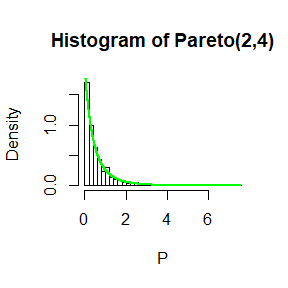

```r
generate.repar.pareto <- function(n, beta, r){
  U <- runif(n)
  P <- beta * (1 / ((1 - U)^(1/r)) - 1)
  return (P)
}

set.seed(929)
beta <- 2; r <- 4
P <- generate.repar.pareto(1e3, beta, r)
hist(P, breaks = 50, prob=TRUE, main="Histogram of Pareto(2,4)")
y <- sort(P)
fy <- r * beta^r * (beta + y)^(-(r + 1))
lines(y, fy, lty=1, col="green", lwd=2)
```

# Homework 2

## 5.1

Compute a Monte Carlo estimate of
$$\int_{0}^{\pi/3} \sin t dt$$
and compare your estimate with the exact value of the integral.

$\textbf{Solution:}$

```r
set.seed(1013)
m <- 10000
U <- runif(m, 0, pi/3)
theta.hat <- pi/3 * mean(sin(U))
theta.exact <- integrate(function(x){sin(x)}, 0, pi/3)$value
cat("The estimated value of the integral is", theta.hat)
```

```
#> The estimated value of the integral is 0.500367
```

```r
cat("The exact value of the integral is", theta.exact)
```

```
#> The exact value of the integral is 0.5
```

## 5.7

Refer to Exercise 5.6. Use a Monte Carlo simulation to estimate $\theta$ by the antithetic variate approach and by the simple Monte Carlo method, where
$$\theta=\int_{0}^{1} e^x dx.$$
Compute an empirical estimate of the percent reduction in variance using the antithetic variate. Compare the result with the theoretical value from Exercise 5.6.

$\textbf{Solution:}$

$\text{Cov}(e^U, e^{1-U})=E(e^Ue^{1-U}) - E(e^U)E(e^{1-U})=e-(e-1)^2.$

$\text{Var}(e^U)=\text{Var}(e^{1-U})=E(e^{2U}) - (E(e^U))^2=\frac12(e^2-1)-(e-1)^2.$

Suppose $\hat{\theta}_1$ is the simple MC estimator and $\hat{\theta}_2$ is the antithetic estimator, then the variance can be calculated:

$$\text{Var}(\hat{\theta}_1)=\text{Var}(\frac{1}{2}(e^U + e^U))=\frac{1}{2}\text{Var}(e^U)=\frac{1}{2}(\frac12(e^2-1)-(e-1)^2)=\frac{1}{2}(-\frac{1}{2}e^2+2e-\frac{3}{2}).$$

$$\text{Var}(\hat{\theta}_2)=\text{Var}(\frac{1}{2}(e^U+e^{1-U}))=\frac{1}{4}(2\text{Var}(e^U)+2\text{Cov}(e^U, e^{1-U}))=\frac{1}{2}(-\frac{3}{2}e^2 + 5e - \frac{5}{2}).$$

The theoretical variace reduction is
$$\frac{\text{Var}(\hat{\theta}_1)-\text{Var}(\hat{\theta}_2)}{\text{Var}(\hat{\theta}_1)}=\frac{e^2 - 3e + 1}{\frac{1}{2}e^2 + 2e - \frac{3}{2}}=0.9676701$$

```r
set.seed(1014)
MC.integral <- function(R = 10000, antithetic = TRUE) {
  u <- runif(R/2, 0, 1)
  if (!antithetic) v <- runif(R/2) else v <- 1 - u
  u <- c(u, v)
  integral <- mean(exp(u))
  integral
}
MC.anti <- MC.mc <- numeric(1000)
for (i in 1:1000){
  MC.anti[i] <- MC.integral(10000, antithetic = TRUE)
  MC.mc[i] <- MC.integral(10000, antithetic = FALSE)
}
cat("The empirical percent of variance reduction using antithetic variate is",
    (var(MC.mc) - var(MC.anti)) / var(MC.mc))
```

```
#> The empirical percent of variance reduction using antithetic variate is 0.9643701
```

```r
cat("The theoretical percent of variance reduction using antithetic variate is",
    (exp(1)^2 - 3*exp(1) + 1) / (-1/2*exp(1)^2 + 2*exp(1) - 3/2))
```

```
#> The theoretical percent of variance reduction using antithetic variate is 0.9676701
```

```r
cat("The estimate using simple Monte Carlo method is", mean(MC.mc), "\n",
    "the estimate using antithetic variate is", mean(MC.anti), "\n",
    "the theoretical value is", exp(1) - 1, "\n")
```

```
#> The estimate using simple Monte Carlo method is 1.718366
#>  the estimate using antithetic variate is 1.718243
#>  the theoretical value is 1.718282
```

## 5.11

If $\hat{\theta}_1$ and $\hat{\theta}_2$ are unbiased estimators of $\theta$, and $\hat{\theta}_1$ and $\hat{\theta}_2$ are antithetic, we derived that $c^{*}=1/2$ is the optimal constant that minimizes the variance of $\hat{\theta}_c=c\hat{\theta}_1+(1-c)\hat{\theta}_2$. Derive $c^{*}$ for the general case.

$\textbf{Solution:}$

$$\begin{aligned}
\text{Var}(\hat{\theta}_c) &= \text{Var}(c\hat{\theta}_1 + (1-c)\hat{\theta}_2) \\
&= c^2 \text{Var}(\hat{\theta}_1) + (1-c)^2\text{Var}(\hat{\theta}_2) + 2c(1-c)\text{Cov}(\hat{\theta}_1, \hat{\theta}_2) \\
&= \left(\text{Var}(\hat{\theta}_1) + \text{Var}(\hat{\theta}_2) - 2\text{Cov}(\hat{\theta}_1, \hat{\theta}_2) \right) c^2 + 2(\text{Cov}(\hat{\theta}_1, \hat{\theta}_2)-\text{Var}(\hat{\theta}_2))c - \text{Var}(\hat{\theta}_2) \\
&= \text{Var}(\hat{\theta}_1 - \hat{\theta}_2) c^2 + 2(\text{Cov}(\hat{\theta}_1, \hat{\theta}_2)-\text{Var}(\hat{\theta}_2))c - \text{Var}(\hat{\theta}_2).
\end{aligned}$$

Treat the formula above as a quadratic function of $c$. Obviously, the function reaches its minimum at
$$c^*=-\frac{\text{Cov}(\hat{\theta}_1, \hat{\theta}_2)-\text{Var}(\hat{\theta}_2)}{\text{Var}(\hat{\theta}_1 - \hat{\theta}_2)}.$$

# Homework 3

## 5.13

Find two importance functions $f_1$ and $f_2$ that are supported on $(1, \infty)$ and are ‘close’ to
$$g(x)=\frac{x^2}{\sqrt{2\pi}}e^{-x^2/2}, x>1$$
. Which of your two importance functions should produce the smaller variance in estimating
$$g(x)=\frac{x^2}{\sqrt{2\pi}}e^{-x^2/2}, x>1$$
by importance sampling? Explain.

$\textbf{Solution:}$

First, display a graph of $g(x)$ to observe its shape.

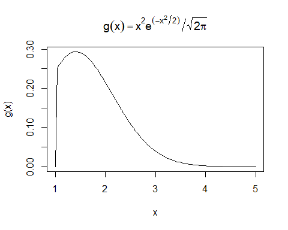

```r
g <- function(x){
  return (x^2*exp(-x^2/2) / sqrt(2*pi) * (x>1))
}

curve(g(x), 1, 5, lty=1, col=1, main=expression(g(x)==x^2*e^(-x^2/2) / sqrt(2*pi)))
```

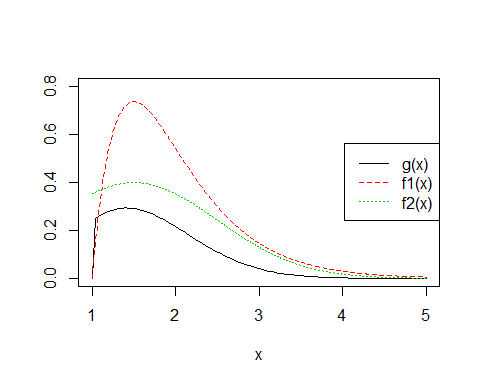

```r
x <- seq(1, 5, 0.01)
curve(g(x), 1, 5, lty=1, col=1, ylim=c(0,0.8), ylab="")
lines(x, dgamma(x - 1, 2, 2), lty=2, col=2)
lines(x, dnorm(x, 1.5, 1), lty=3, col=3)
legend("right", legend=c("g(x)", "f1(x)", "f2(x)"), lty=c(1,2,3), col=c(1,2,3))
```

We should expect that $f_2(x)$ can produce smaller variance because $g(x) / f_2(x)$ is closer to a constant function than $g(x) / f_1(x)$.

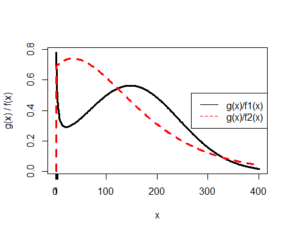

```r
x <- seq(1, 5, 0.01)
plot(g(x) / dgamma(x - 1, 1.5, 2),
     type="l", lty=1, col=1, lwd=3, xlab="x", ylab="g(x) / f(x)")
lines(g(x) / dnorm(x, 1.5, 1), lty=2, col=2, lwd=3)
legend("right", c("g(x)/f1(x)", "g(x)/f2(x)"), lty=c(1, 2), col=c(1, 2))
axis(1, at=c(1:5))
```

## 5.15

Obtain the stratified importance sampling estimate of
$$\int_{0}^{1} \frac{e^{-x}}{1+x^2}dx.$$
and compare it with the result of Example 5.10.

$\textbf{Solution:}$

First, we should make some correction for the density function. On the $j^{th}$ subinterval, variables are generated from density function
$$f_j(x)=\frac{e^{-x}}{e^{-(j-1)/5} - e^{-j/5}}, x \in [\frac{j-1}{5}, \frac{j}{5}].$$

```r
set.seed(1020)
SISE <- function(k){
  M <- 1e4
  m <- M / k
  si <- v <- numeric(k)

  g <- function(x) exp(-x) / (1 + x^2)
  f <- function(x, j) exp(-x) / (exp(-(j - 1) / k) - exp(-j / k))

  for (j in 1:k){
    r <- runif(m, (j-1) / k, j / k)
    x <- -log(exp(-(j - 1) / k) - (exp(-(j - 1) / k) - exp(-j / k))*r)
    gf <- g(x) / f(x, j)
    si[j] <- mean(gf)
    v[j] <- var(gf)
  }
  return (list(si=si, v=v))
}

result.sise <- SISE(5)
cat("The value of integral is ", sum(result.sise$si), "\n")
```

```
#> The value of integral is  0.5241767
```

```r
cat("The estimated variance is ", mean(result.sise$v))
```

```
#> The estimated variance is  4.388291e-07
```

If we use importance function $f_3(x)=e^{-x} / (1-e^{-1})$ and without stratification, the estimated value of integral and its variance can be calculated as follows:

```r
set.seed(1020)
result.sise <- SISE(1)
cat("The value of integral is ", sum(result.sise$si), "\n")
```

```
#> The value of integral is  0.5232581
```

```r
cat("The estimated variance is ", mean(result.sise$v))
```

```
#> The estimated variance is  0.00957218
```

It can be seen that SISE has smaller variance than the estimate without stratification.

## 6.4

Suppose that $X_1,\cdots,X_n$ are a random sample from a lognormal distribution with unknown parameters. Construct a 95% confidence interval for the parameter $\mu$. Use a Monte Carlo method to obtain an empirical estimate of the confidence level.

$\textbf{Solution:}$

We know that if $X \sim lognormal(\mu, \sigma^2)$, $\ln X \sim N(\mu, \sigma^2).$ Let $Y_i = \ln X_i$, then we can treat this problem of as giving a confidence interval of $\mu$ when $\sigma^2$ is unknown under normal distribution. It is easy to derive that
$$\frac{\bar{Y}-\mu}{W / \sqrt{n}} \sim t(n-1),$$
where
$$W^2=\frac{1}{n-1}\sum_{i=1}^{n}(\ln X_i - \frac{1}{n}\sum_{i=1}^{n} \ln X_i)^2.$$
So, the $100(1-\alpha)$% confidence interval of $\mu$ is
$$\left(\frac{1}{n}\sum_{i=1}^{n} \ln X_i - t_{1-\alpha/2}(n-1) \frac{W}{\sqrt{n}},\frac{1}{n}\sum_{i=1}^{n} \ln X_i + t_{1-\alpha/2}(n-1) \frac{W}{\sqrt{n}} \right).$$

In the following experiment, we set true $\mu=0, \sigma=1$, and calculate the empirical covering probability. The empirical confidence level is 0.9496.

```r
set.seed(1020)
n <- 20
CI <- replicate(1e4, expr={
  x <- rlnorm(n)
  y <- log(x)
  ybar <- mean(y)
  se <- sd(y) / sqrt(n)
  ybar + se * qt(c(0.025, 0.975), df=n-1)
})
L <- CI[1, ]
U <- CI[2, ]
cover <- sum((L <= 0) & (U >= 0))
cat("The empirical covering probability is", cover / ncol(CI))
```

```
#> The empirical covering probability is 0.9496
```

## 6.5

Suppose a 95% symmetric $t$-interval is applied to estimate a mean, but the sample data are non-normal. Then the probability that the confidence interval covers the mean is not necessarily equal to 0.95. Use a Monte Carlo experiment to estimate the coverage probability of the $t$-interval for random samples of $\chi^2(2)$ data with sample size $n=20$. Compare your $t$-interval results with the simulation results in Example 6.4. (The $t$-interval should be more robust to departures from normality than the interval for variance.)

$\textbf{Solution:}$

There are 92.34% of intervals that contain true mean value $\mu=2$. In Example 6.4, there are only 77.3% of intervals that contain true variance $\sigma^2=4$. This shows that $t$-interval is more robust to departures from normality than the interval for variance.

```r
set.seed(1020)
library(dplyr)
m <- 1e4
n <- 20
mu <- 2
cover <- 0
interval <- replicate(m, expr={
  x <- rchisq(n, df=2)
  mean(x) + qt(c(0.025, 0.975), df=n-1) * sd(x) / sqrt(n)
})
for (i in 1:m){
  cover <- cover + between(mu, interval[, i][1], interval[, i][2])
}
cat("The empirical covering probability is ", cover / m)
```

```
#> The empirical covering probability is  0.9234
```

# Homework 4

## 6.7

Estimate the power of the skewness test of normality against symmetric Beta($\alpha$, $\alpha$) distributions and comment on the results. Are the results different for heavy-tailed symmetric alternatives such as $t(\nu)$?

$\textbf{Solution:}$

In this simulation, let sample size $n=30$, $\alpha$ and $\nu$ vary from 1 to 10. For every $\alpha$($\mu$), repeat the experiment 10000 times.

For Beta($\alpha, \alpha$):

```r
set.seed(1027)
library(e1071) #for `skewness()` function`
n <- 30
ab <- 1:10
m <- 1e4
cv <- qnorm(1 - 0.05/2, 0, sqrt(6 * (n - 2) / ((n + 1)*(n + 3))))
pwr.beta <- numeric(length(ab))
sktest <- numeric(m)

for (i in 1:length(ab)){
  a <- ab[i]
  sktest <- replicate(m, expr={
    x <- rbeta(n, shape1 = a, shape2 = a)
    as.integer(abs(skewness(x)) >= cv)
  })
  pwr.beta[i] <- mean(sktest)
}
```

For $t(\nu)$:

```r
pwr.t <- numeric(length(ab))
sktest <- numeric(m)

for (i in 1:length(ab)){
  nu <- ab[i]
  sktest <- replicate(m, expr={
    x <- rt(n, df=nu)
    as.integer(abs(skewness(x)) >= cv)
  })
  pwr.t[i] <- mean(sktest)
}
```

We can make a plot of the power vs. degrees of freedom.

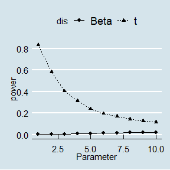

```r
library(ggpubr)
d <- data.frame(df=rep(ab, time=2),
                pwr=c(pwr.beta, pwr.t),
                dis=rep(c("Beta", "t"), each=10))
ggline(d, x="df", y="pwr", group="dis", linetype="dis", shape="dis",
       palette = c("#00AFBB", "#E7B800"),
       xlab="Parameter", ylab="power") + ggthemes::theme_economist()
```

For Beta$(\alpha, \alpha)$ distribution, the power of the test is constantly small for $\alpha$ varying from 1 to 10. But for $t(\nu)$ distribution, the test is more powerful when the degrees of freedom are small. As $\nu$ grows larger, the power tends to $\alpha$.

## 6.8

Refer to Example 6.16. Repeat the simulation, but also compute the F test of equal variance, at significance level $\hat{\alpha} = 0.055$. Compare the power of the Count Five test and F test for small, medium, and large sample sizes. (Recall that the F test is not applicable for non-normal distributions.)

$\textbf{Solution:}$

```r
set.seed(1027)
alpha.hat <- 0.055
n <- c(10, 20, 50, 100, 500, 1000)
mu1 <- mu2 <- 0
sigma1 <- 1
sigma2 <- 1.5
m <- 1e4
result <- matrix(0, length(n), 2)

count5test <- function(x, y){
  X <- x - mean(x)
  Y <- y - mean(y)
  outx <- sum(X > max(Y)) + sum(X < min(Y))
  outy <- sum(Y > max(X)) + sum(Y < min(X))
  return (as.integer(max(c(outx, outy)) > 5))
}

for (i in 1:length(n)){
  ni <- n[i]
  tests <- replicate(m, expr={
    x <- rnorm(ni, mu1, sigma1)
    y <- rnorm(ni, mu2, sigma2)
    Fp <- var.test(x, y)$p.value
    Ftest <- as.integer(Fp <= alpha.hat)
    c(count5test(x, y), Ftest)
  })
  result[i, ] <- rowMeans(tests)
}

data.frame(n=n, C5=result[, 1], Fp=result[, 2])
```

```
#>      n     C5     Fp
#> 1   10 0.1050 0.2101
#> 2   20 0.3128 0.4248
#> 3   50 0.6584 0.8181
#> 4  100 0.8546 0.9812
#> 5  500 0.9902 1.0000
#> 6 1000 0.9977 1.0000
```

The simulation results suggest that the F-test for equal variance is more powerful in this case, for all sample sizes compared.

## Discussion

If we obtain the powers for two methods under a particular simulation setting with 10,000 experiments: say, 0.651 for one method and 0.676 for another method. Can we say the powers are different at 0.05 level?

- What is the corresponding hypothesis test problem?
- What test should we use? Z-test, two-sample t-test, paired-t test or McNemar test?
- What information is needed to test your hypothesis?

$\textbf{Solution:}$

- According to the definition of power, it is the proportion that we reject $H_0$ given $H_0$ is not true. Thus, we can treat this problem as
  $$H_0:p_1=p_2 \quad vs. \quad H_1:p_1 \neq p_2.$$
  Where $p_1$ is the proportion of rejecting $H_0$ using method 1, and $p_2$ is the proportion of rejecting $H_0$ using method 2. From another perspective, let $d$ be the total number of different test results using two methods, i.e., if $H_0$ is rejected under one of the two methods but not rejected under the other method, $d_i=1$, otherwise $d_i=0$. Then let $d=\sum_{i=1}^{n}d_i.$ In this situation, the problem can be written as $H_0:d=0 \quad vs. \quad H_1:d >0.$
- We should use Z-test. The test statistic is
  $$z=\frac{p_1 - p_2}{\sqrt{\frac{p_1(1-p_1)}{n_1} + \frac{p_2(1-p_2)}{n_2}}} \sim N(0,1).$$
  Paired $t$-test is also OK for this hypothesis test if we want to test $H_0:d=0 \quad vs. \quad H_1:d >0.$ The test statistic is
  $$t=\frac{\bar{d}}{s_d / \sqrt{n}} \sim t(n-1),$$
  where $\bar{d}=\frac{1}{n}\sum_{i=1}^{d}d_i, s_d=\left(\frac{1}{n-1}\sum_{i=1}^{n}(d_i-\bar{d})^2\right)^{1/2}.$
- If we use Z-test, we will need no additional information. If we use paired t-test, we will need the paired difference vector $\boldsymbol{d}=(d_1,\cdots,d_n)$.

# Homework 5

## 7.1

Using data `law` in package `bootstrap`, Compute a jackknife estimate of the bias and the standard error of the correlation statistic.

$\textbf{Solution:}$

```r
data(law, package = "bootstrap")
n <- nrow(law)
R.hat <- cor(law$LSAT, law$GPA)
R.jack <- numeric(n)

for (i in 1:n){
  x <- law[-i, ]
  R.jack[i] <- cor(x[, 1], x[, 2])
}

bias.jack <- (n - 1)*(mean(R.jack) - R.hat)
se.jack <- sqrt(var(R.jack) * (n-1)^2 / n)
cat("The jackknife estimate of the bias of correlation statistic is", bias.jack, "\n")
```

```
#> The jackknife estimate of the bias of correlation statistic is -0.006473623
```

```r
cat("The jackknife estimate of the standard error of correlation statistic is", se.jack)
```

```
#> The jackknife estimate of the standard error of correlation statistic is 0.1425186
```

## 7.5

Refer to the air-conditioning data set `aircondit` provided in the `boot` package. Compute 95% bootstrap confidence intervals for the mean time between failures $\frac{1}{\lambda}$ by the standard normal, basic, percentile, and BCa methods. Compare the intervals and explain why they may differ.

$\textbf{Solution:}$

```r
set.seed(113)
library(boot)
data(aircondit, package="boot")
x <- aircondit$hours

boot.func <- function(x, i){
  mean(as.matrix(x[i]))
}

b <- boot(
  data = x,
  statistic = boot.func,
  R = 1000
)

boot.ci(b, type=c("norm", "perc", "basic", "bca"))
```

```
#> BOOTSTRAP CONFIDENCE INTERVAL CALCULATIONS
#> Based on 1000 bootstrap replicates
#>
#> CALL :
#> boot.ci(boot.out = b, type = c("norm", "perc", "basic", "bca"))
#>
#> Intervals :
#> Level      Normal              Basic
#> 95%   ( 37.6, 181.7 )   ( 31.7, 169.8 )
#>
#> Level     Percentile            BCa
#> 95%   ( 46.3, 184.5 )   ( 59.1, 218.1 )
#> Calculations and Intervals on Original Scale
#> Some BCa intervals may be unstable
```

We can make a QQ-plot to examine whether the data is normally distributed.

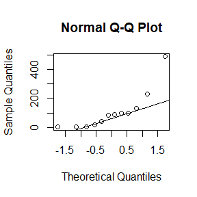

```r
qqnorm(x);qqline(x)
```

From the QQ-plot, the data is obviously not normal. So the normal interval is not so good. BCa interval adjusts for bias and skewness, so it may be better than percentile interval.

## 7.8

Obtain the jackknife estimates of bias and standard error of
$$\hat{\theta}=\frac{\hat{\lambda}_1}{\sum_{i=1}^{5}\hat{\lambda}_j}.$$

$\textbf{Solution:}$

```r
set.seed(1018)
library(boot)
library(bootstrap)
data(scor, package="bootstrap")

n <- nrow(scor)
df <- as.data.frame(scor)
theta.hat <- eigen(cov(df))$value[1] / sum(eigen(cov(df))$value)

## jackknife estimate
theta.j <- rep(0, n)
for (i in 1:n){
  x <- df[-i, ]
  lambda <- eigen(cov(x))$values
  theta.j[i] <- lambda[1] / sum(lambda)
}
bias.jack <- (n - 1) * (mean(theta.j) - theta.hat)
se.jack <- (n - 1) * sqrt(var(theta.j) / n)

cat("The jackknife estimate of bias is", bias.jack, "\n")
```

```
#> The jackknife estimate of bias is 0.001069139
```

```r
cat("The jackknife estimate of standard error is", se.jack)
```

```
#> The jackknife estimate of standard error is 0.04955231
```

## 7.11

In Example 7.18, leave-one-out (n-fold) cross validation was used to select the best fitting model. Use leave-two-out cross validation to compare the models.

$\textbf{Solution:}$

```r
if (!require(DAAG)) {
  install.packages("DAAG")
  library(DAAG)
}
data(ironslag)
n <- nrow(ironslag)
N <- combn(n, 2) #choose all possible combinations C_{n}^{2}
e1 <- e2 <- e3 <- e4 <- numeric(dim(N)[2])

for (k in 1:dim(N)[2]){
  lto <- N[, k] # leave-two-out index
  y <- ironslag[-lto, 2]
  x <- ironslag[-lto, 1]

  J1 <- lm(y ~ x)
  yhat1 <- J1$coef[1] + J1$coef[2]*ironslag[lto, 1]
  e1[k] <- sum((ironslag[lto, 2] - yhat1)^2)

  J2 <- lm(y ~ (x + I(x^2)))
  yhat2 <- J2$coef[1] + J2$coef[2] * ironslag[lto, 1] + J2$coef[3] * ironslag[lto, 1]^2
  e2[k] <- sum((ironslag[lto, 2] - yhat2)^2)

  J3 <- lm(log(y) ~ x)
  logyhat3 <- J3$coef[1] + J3$coef[2]*ironslag[lto, 1]
  yhat3 <- exp(logyhat3)
  e3[k] <- sum((ironslag[lto, 2] - yhat3)^2)

  J4 <- lm(log(y) ~ log(x))
  logyhat4 <- J4$coef[1] + J4$coef[2]*log(ironslag[lto, 1])
  yhat4 <- exp(logyhat4)
  e4[k] <- sum((ironslag[lto, 2] - yhat4)^2)
}

c(mean(e1), mean(e2), mean(e3), mean(e4))
```

```
#> [1] 39.14455 35.74037 36.90983 40.93436
```

Based on minimum prediction error criterion, the minimum prediction error is 35.74037. So we should choose a linear model with quadratic form. We can then use all data to build this model.

```r
model <- lm(magnetic~chemical + I(chemical^2), data=ironslag)
summary(model)
```

```
#>
#> Call:
#> lm(formula = magnetic ~ chemical + I(chemical^2), data = ironslag)
#>
#> Residuals:
#>     Min      1Q  Median      3Q     Max
#> -8.4335 -2.7006 -0.2754  2.5446 12.2665
#>
#> Coefficients:
#>               Estimate Std. Error t value Pr(>|t|)
#> (Intercept)   24.49262    9.14657   2.678   0.0100 **
#> chemical      -1.39334    0.88852  -1.568   0.1232
#> I(chemical^2)  0.05452    0.02081   2.620   0.0116 *
#> ---
#> Signif. codes:  0 '***' 0.001 '**' 0.01 '*' 0.05 '.' 0.1 ' ' 1
#>
#> Residual standard error: 4.098 on 50 degrees of freedom
#> Multiple R-squared:  0.5931, Adjusted R-squared:  0.5768
#> F-statistic: 36.44 on 2 and 50 DF,  p-value: 1.728e-10
```

If we use $Y$ to represent `magnetic`, $X$ to represent `chemical`, the model can be written as
$$Y=24.49-1.39X+0.05X^2.$$

# Homework 6

## 8.3

The Count 5 criterion is not applicable for unequal sample sizes. Implement a permutation test for equal variance that is based on the maximum outliers statistic that applies when sample sizes are not necessarily equal.

$\textbf{Solution:}$

First, compute the maximum outlier statistic based on permutation.

```r
max.extreme.points <- function(x, y){
  X <- x - mean(x)
  Y <- y - mean(y)
  outx <- sum(X > max(Y)) + sum(X < min(Y))
  outy <- sum(Y > max(X)) + sum(Y < min(X))
  max(c(outx, outy))
}


maxout <- function(x, y, R){

  # x: a vector representing a sample from population 1
  # y: a vector representing a sample from population 2
  # R: the number of replicates
  # return: a list containing the `maxout` statistic and p value of the permutation test

  z <- c(x, y)
  n <- length(x)
  N <- length(z)

  stat <- replicate(R, expr={
    k <- sample(c(1:N))
    k1 <- k[1:n]
    k2 <- k[(n+1):N]
    max.extreme.points(z[k1], z[k2])
  })
  stat1 <- max.extreme.points(x, y)
  stat2 <- c(stat, stat1)

  return (list(estimate=stat1,
               p.val=mean(stat2 >= stat1)))
}
```

```r
set.seed(1110)
n <- 30
m <- 60
mu1 <- mu2 <- 0
sigma1 <- sigma2 <- 1
x <- rnorm(n, mu1, sigma1)
y <- rnorm(m, mu2, sigma2)
maxout(x, y, 500)
```

```
#> $estimate
#> [1] 4
#>
#> $p.val
#> [1] 0.5528942
```

In the second example, suppose that the variances of two populations are unequal, where $\sigma_1^2=1, \sigma_2^2=4$. The sample sizes are $n=30, m=60$ respectively. Do 500 replicates in this test. The p-value of this test is 0.002, so the observed statistic is significant.

```r
sigma1 <- 1
sigma2 <- 2
x <- rnorm(n, mu1, sigma1)
y <- rnorm(m, mu2, sigma2)
maxout(x, y, 500)
```

```
#> $estimate
#> [1] 21
#>
#> $p.val
#> [1] 0.001996008
```

# Homework 7

## 9.4b

For Exercise 9.4a, use the Gelman-Rubin method to monitor convergence of the chain, and run the chain until it converges approximately to the target distribution according to $\hat{R} < 1.2$.

$\textbf{Solution:}$

From exercise 9.4a, we know that $\sigma=1$ and $\sigma=2$ can fit the target distribution well. In this exercise, let the length of the chain be $N=1000$, the standard deviation of proposal distribution be $\sigma=2$. Run 3 Markov Chains simultaneously. Use package `coda` to check the convergence of the chain.

```r
set.seed(1117)

m <- 3 # number of Markov chains
N <- 1000 # the length of each chain
sigma <- 2 # the standard deviation of proposal distribution
X <- matrix(0, nrow=m, ncol=N) # matrix for storing Markov chains
x0 <- 2 # initial value for the chains

rw.Metropolis <- function(sigma, x0, N){
  # sigma is the standard deviation of proposal distribution N(X_t, \sigma^2)
  # x0 is the starting point when implementing sampling
  # N is the length of the chain

  x <- numeric(N)
  x[1] <- x0
  u <- runif(N)
  k <- 0
  for (i in 2:N){
    y <- rnorm(1, x[i - 1], sigma)
    if (u[i] <= exp(abs(x[i - 1]) - abs(y))){
      x[i] <- y
    }else{
      x[i] <- x[i - 1]
    }
  }

  return (x)
}


for (j in 1:m){
  X[j, ] <- rw.Metropolis(sigma, x0, N)
}

library(coda)
X1 <- as.mcmc(X[1, ])
X2 <- as.mcmc(X[2, ])
X3 <- as.mcmc(X[3, ])
Y <- mcmc.list(X1, X2, X3)
print(gelman.diag(Y))
```

```
#> Potential scale reduction factors:
#>
#>      Point est. Upper C.I.
#> [1,]       1.03       1.03
```

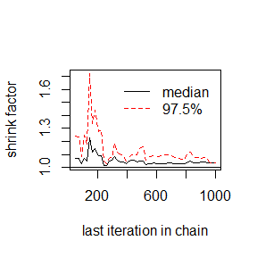

```r
gelman.plot(Y, col=c(1, 2))
```

It can be seen that for iterations=1000, the Gelman-Rubin statistic is 1.03. From the Gelman-Rubin plot, the chains converge to the target distribution after about 300 iterations.

# Homework 8

## A-B-O blood type problem

1. Use EM algorithm to solve MLE of $p$ and $q$.
2. Record the values of $p$ and $q$ that maximize the conditional likelihood in each EM steps, calculate the corresponding log-maximum likelihood values(for observed data), are they increasing?

$\textbf{Solution:}$

1. Note that $n_{AA}$ and $n_{BB}$ are missing, and the constraint $p+q+r=1$ holds, the complete data likelihood can be written as
   $$\begin{aligned}
   L_c(p, q) &= (p^2)^{n_{AA}}(q^2)^{n_{BB}}(r^2)^{n_{OO}}(2pr)^{n_{AO}}(2qr)^{n_{BO}}(2pq)^{n_{AB}} \\
   &= (p^2)^{n_{A\cdot} - n_{AO}}(q^2)^{n_{B \cdot} - n_{BO}} (r^2)^{n_{OO}}(2pr)^{n_{AO}}(2qr)^{n_{BO}}(2pq)^{n_{AB}} \\
   &= (p^2)^{n_{A \cdot}} (\frac{2r}{p})^{n_{AO}} (q^2)^{n_{B \cdot}} (\frac{2r}{q})^{n_{BO}} (r^2)^{n_{OO}} (2pq)^{n_{AB}} \\
   & \propto (p^2)^{n_{A \cdot}} (\frac{r}{p})^{n_{AO}} (q^2)^{n_{B \cdot}} (\frac{r}{q})^{n_{BO}} (r^2)^{n_{OO}} (pq)^{n_{AB}}.
   \end{aligned}$$
   The log likelihood of $L_c(p, q)$ is
   $$\ell_c(p,q) = 2n_{A \cdot} \ln p + n_{AO} \ln(r/p) + 2n_{B \cdot} \ln q + n_{BO} \ln(r/q) + 2n_{OO} \ln r + n_{AB} \ln(pq).$$

Given an initial estimate of $p, q$, named $\hat{p}_{0}, \hat{q}_{0}$, the E-step can be written as
$$\begin{aligned}
& E_{\hat{p}_0, \hat{q}_0}[\ell_c(p,q)|n_{A \cdot}, n_{B \cdot}, n_{OO}, n_{AB}] \\
&= 2n_{A \cdot} \ln p + 2n_{B \cdot} \ln q + 2n_{OO} \ln r + n_{AB} \ln(pq) \\
&+ E_{\hat{p}_0, \hat{q}_0}[n_{AO} \ln(r/p)|n_{A \cdot}, n_{B \cdot}, n_{OO}, n_{AB}] + E_{\hat{p}_0, \hat{q}_0}[n_{BO} \ln(r/q)|n_{A \cdot}, n_{B \cdot}, n_{OO}, n_{AB}] \\
&= 2n_{A \cdot} \ln p + 2n_{B \cdot} \ln q + 2n_{OO} \ln r + n_{AB} \ln(pq) \\
+ &n_{A \cdot} \frac{2\hat{p}_0(1-\hat{p}_0 - \hat{q}_0)}{2\hat{p}_0(1-\hat{p}_0 - \hat{q}_0) + \hat{p}_0^2} \ln (r/p) + n_{B \cdot}\frac{2\hat{q}_0(1-\hat{p}_0 - \hat{q}_0)}{2\hat{q}_0(1-\hat{p}_0 - \hat{q}_0) + \hat{q}_0^2} \ln(r/q),
\end{aligned}$$
this is due to the fact that $n_{AO} | n_{A \cdot}, n_{B \cdot}, n_{OO}, n_{AB} \sim B(n_{A \cdot}, \frac{2pr}{2pr + p^2}), n_{BO} | n_{A \cdot}, n_{B \cdot}, n_{OO}, n_{AB} \sim B(n_{B \cdot}, \frac{2qr}{2qr + q^2}).$

In M-step, take partial derivatives of $Q=E_{\hat{p}_0, \hat{q}_0}[\ell_c(p,q)|n_{A \cdot}, n_{B \cdot}, n_{OO}, n_{AB}]$ with respect to $p$ and $q$. Let $\alpha=n_{A \cdot} \frac{2\hat{p}_0(1-\hat{p}_0 - \hat{q}_0)}{2\hat{p}_0(1-\hat{p}_0 - \hat{q}_0) + \hat{p}_0^2}, \beta=n_{B \cdot}\frac{2\hat{q}_0(1-\hat{p}_0 - \hat{q}_0)}{2\hat{q}_0(1-\hat{p}_0 - \hat{q}_0) + \hat{q}_0^2},$ then
$$\begin{aligned}
\frac{\partial Q}{\partial p} &= \frac{2n_{A \cdot}}{p} - \frac{2n_{OO}}{1-p-q} + n_{AB} \frac{q}{pq} + \alpha \frac{\frac{(q-1)}{p^2}}{\frac{(1-p-q)}{p}} + \beta \frac{\frac{-1}{q}}{\frac{(1-p-q)}{q}} \\
&= \frac{2n_{A \cdot}}{p} - \frac{2n_{OO}}{1-p-q} + \frac{n_{AB}}{p} + \alpha \frac{q-1}{p(1-p-q)} - \beta \frac{1}{1-p-q}.
\end{aligned}$$
$$\begin{aligned}
\frac{\partial Q}{\partial q} &= \frac{2n_{B \cdot}}{q} - \frac{2n_{OO}}{1-p-q} + n_{AB} \frac{p}{pq} + \alpha \frac{\frac{-1}{p}}{\frac{(1-p-q)}{p}} + \beta \frac{\frac{(p-1)}{q^2}}{\frac{(1-p-q)}{q}} \\
&= \frac{2n_{B \cdot}}{q} - \frac{2n_{OO}}{1-p-q} + \frac{n_{AB}}{q} - \alpha \frac{1}{1-p-q} + \beta \frac{p-1}{q(1-p-q)}.
\end{aligned}$$

Let $\frac{\partial Q}{\partial p}=0$ and $\frac{\partial Q}{\partial q}=0$, and after some simplification, we can get
$$\begin{aligned}
(2n_{A \cdot} + n_{AB} + 2n_{OO} + \beta)p + (2n_{A \cdot} + n_{AB} - \alpha)q &= -\alpha + 2n_{A \cdot} + n_{AB}, \\
(2n_{B \cdot} + n_{AB} - \beta)p + (2n_{B \cdot} + n_{AB} + 2n_{OO} + \alpha)q &= -\beta + 2n_{B \cdot} + n_{AB}.
\end{aligned}$$

By solving the linear equation system, we have
$$\begin{aligned}
p &= \frac{\begin{vmatrix}
-\alpha + 2n_{A \cdot} + n_{AB} & 2n_{A \cdot} + n_{AB} - \alpha \\
-\beta + 2n_{B \cdot} + n_{AB} & 2n_{B \cdot} + n_{AB} + 2n_{OO} + \alpha
\end{vmatrix}}{\begin{vmatrix}
2n_{A \cdot} + n_{AB} + 2n_{OO} + \beta & 2n_{A \cdot} + n_{AB} - \alpha \\
2n_{B \cdot} + n_{AB} - \beta & 2n_{B \cdot} + n_{AB} + 2n_{OO} + \alpha
\end{vmatrix}}, \\
q &= \frac{\begin{vmatrix}
2n_{A \cdot} + n_{AB} + 2n_{OO} + \beta & -\alpha + 2n_{A \cdot} + n_{AB}\\
2n_{B \cdot} + n_{AB} - \beta & -\beta + 2n_{B \cdot} + n_{AB}
\end{vmatrix}}{\begin{vmatrix}
2n_{A \cdot} + n_{AB} + 2n_{OO} + \beta & 2n_{A \cdot} + n_{AB} - \alpha \\
2n_{B \cdot} + n_{AB} - \beta & 2n_{B \cdot} + n_{AB} + 2n_{OO} + \alpha
\end{vmatrix}}
\end{aligned}$$

From the observed data, we can get the MLE of $r$, $\hat{r}=\sqrt{\frac{n_{OO}}{n}}.$ Since $p$ and $q$ satisfy
$$\begin{aligned}
p^2 + 2pr = \frac{n_{A\cdot}}{n}, \\
q^2 + 2qr = \frac{n_{B \cdot}}{n}.
\end{aligned}$$
we can give an intuitive initial value of $p$ and $q$
$$\begin{aligned}
\hat{p}_{0} = \frac{-2\hat{r} + \sqrt{(2\hat{r})^2 + 4\frac{n_{A \cdot}}{n}}}{2} \\
\hat{q}_{0} = \frac{-2\hat{r} + \sqrt{(2\hat{r})^2 + 4\frac{n_{B \cdot}}{n}}}{2}.
\end{aligned}$$

2. The conditional log likelihood for observed data is
   $$\ell_O(p, q) = n_{A\cdot}\log(p^2 + 2pr) + n_{B\cdot}\log(q^2 + 2qr)+ n_{OO}\log(r^2)+ n_{AB}\log(2pq).$$
   Substitute $p$, $q$ and $r$ with $\hat{p}$, $\hat{q}$ and $1 - \hat{p} - \hat{q}$ to compute the log likelihood.

```r
nAdot <- 444
nBdot <- 132
nOO <- 361
nAB <- 63
n <- nAdot + nBdot + nOO + nAB
rhat <- sqrt(nOO / n)
c1 <- nAdot / n
c2 <- nBdot / n
phat <- (-2*rhat + sqrt((2*rhat)^2 + 4*1*c1)) / 2
qhat <- (-2*rhat + sqrt((2*rhat)^2 + 4*1*c2)) / 2

max.iters <- 20# maximum iterations
p <- phat; q <- qhat # initial value of p and q
result <- matrix(0, max.iters, 3)


for (iter in 1:max.iters){

  alpha <- (nAdot * (2*p*(1-p-q))) / (2*p*(1-p-q) + p^2)
  beta <- (nBdot * (2*q*(1-p-q))) / (2*q*(1-p-q) + q^2)

  nump <- matrix(c(
    -alpha + 2 * nAdot + nAB,
    2 * nAdot + nAB - alpha,
    -beta + 2 * nBdot + nAB,
    2 * nBdot + nAB + 2*nOO + alpha
  ), nrow = 2, byrow = TRUE)

  numq <- matrix(c(
    2 * nAdot + nAB + 2 * nOO + beta,
    -alpha + 2 * nAdot + nAB,
    2 * nBdot + nAB - beta,
    -beta + 2 * nBdot + nAB
  ), nrow = 2, byrow = TRUE)

  denom <- matrix(c(
    2 * nAdot + nAB + 2 * nOO + beta,
    2 * nAdot + nAB - alpha,
    2 * nBdot + nAB - beta,
    2 * nBdot + nAB + 2 * nOO + alpha
  ), nrow = 2, byrow = TRUE)

  p <- det(nump) / det(denom)
  q <- det(numq) / det(denom)
  r <- 1 - p - q
  loglik <- nAdot*log(p^2 + 2*p*r) + nBdot*log(q^2 + 2*q*r) +
    nOO*log(r^2) + nAB*log(2*p*q)

  result[iter, 1] <- p
  result[iter, 2] <- q
  result[iter, 3] <- loglik
}

cat("The MLEs of p and q using EM algorithm are ", p, " and ", q)
```

```
#> The MLEs of p and q using EM algorithm are  0.2976407  and  0.1027063
```

Let’s go through the change of log likelihood for observed data. We can see that the log likelihood increases within first 3 iterations and seems unchanged after the 4th iteration. It shows that the EM algorithm converges very quickly.

```r
data.frame(p=result[1:10, 1], q=result[1:10, 2], loglik=result[1:10, 3])
```

```
#>            p         q    loglik
#> 1  0.2973357 0.1026199 -1169.822
#> 2  0.2975814 0.1026991 -1169.822
#> 3  0.2976297 0.1027054 -1169.822
#> 4  0.2976387 0.1027061 -1169.822
#> 5  0.2976403 0.1027062 -1169.822
#> 6  0.2976406 0.1027063 -1169.822
#> 7  0.2976407 0.1027063 -1169.822
#> 8  0.2976407 0.1027063 -1169.822
#> 9  0.2976407 0.1027063 -1169.822
#> 10 0.2976407 0.1027063 -1169.822
```

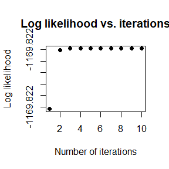

```r
plot(result[, 3][1:10], pch=16,
     main="Log likelihood vs. iterations",
     xlab="Number of iterations", ylab="Log likelihood")
```

## Exercise 3, Page 204

Use both for loops and `lapply()` to fit linear models to the `mtcars` using the formulas stored in this list:

```r
formulas <- list(
  mpg ~ disp,
  mpg ~ I(1 / disp),
  mpg ~ disp + wt,
  mpg ~ I(1 / disp) + wt
)
```

$\textbf{Solution:}$

```r
formulas <- list(
  mpg ~ disp,
  mpg ~ I(1 / disp),
  mpg ~ disp + wt,
  mpg ~ I(1 / disp) + wt
)

# fit linear models using for loops
for (i in 1:4){
  model <- lm(formulas[[i]], data=mtcars)
}

# fit linear models using lapply()
lapply(formulas, function(formula) lm(formula, data=mtcars))
```

[output not shown]

## Exercise 3, Page 213

The following code simulates the performance of a t-test for non-normal data. Use `sapply()` and an anonymous function to extract the p-value from every trial.

```r
trials <- replicate(
  100,
  t.test(rpois(10, 10), rpois(7, 10)),
  simplify = FALSE
)
```

$\textbf{Solution:}$

```r
trials <- replicate(
  100,
  t.test(rpois(10, 10), rpois(7, 10)),
  simplify = FALSE
)

# extract the p-value using sapply()
# using anonymous function
p.val.ano <- sapply(trials, function(x) x$p.value)
# using [[
p.val <- sapply(trials, "[[", "p.value")

# check if `p.val.ano` and `p.val` are identical
all(p.val.ano == p.val)
```

```
#> [1] TRUE
```

## Exercise 6, Page 214

Implement a combination of `Map()` and `vapply()` to create an `lapply()` variant that iterates in parallel over all of its inputs and stores its outputs in a vector(or a matrix). What arguments should the function take?

$\textbf{Solution:}$

The function `mylapply` iterates over the list X, whose elements are all lists(data frames), and do the same operation for all of its elements. The function takes four arguments, `X` is the input data, `FUN` is the operation to impose on the input, `FUN.VALUE` is the same meaning as `vapply()` and `simplify` is the indicator to use function `simplify2array()`.

```r
mylapply <- function(X, FUN, FUN.VALUE, simplify = TRUE){
  val <- Map(function(x) vapply(x, FUN, FUN.VALUE), X)
  if (simplify){
    return (simplify2array(val))
  }
  return (val)
}
```

Here is a test example.

```r
ls <- list(mtcars, iris)
mylapply(ls, mean, numeric(1))
```

[output not shown]

# Homework 9

## 9.4

Implement a random walk Metropolis sampler for generating the standard Laplace distribution. For the increment, simulate from a normal distribution. Compare the chains generated when different variances are used for the proposal distribution. Also, compute the acceptance rates of each chain.

- Write an Rcpp function and Compare the corresponding generated random numbers with those by the R function you wrote before using the function “qqplot”.
- Compare the computation time of the two functions with the function “microbenchmark”.
- Comments your results.

$\textbf{Solution:}$

Suppose that $X \sim Laplace(0, 1)$, if $X$ has density function
$$f(x)=\frac{1}{2}e^{-|x|}.$$
Now if we choose a normal distribution $N(X_t, \sigma^2)$ as proposal distribution, then we have
$$r(x_t, y)=\frac{f(y)}{f(x_t)}=\exp\left\{|x_t|-|y|\right\}.$$
The function `rw.Metropolis` is used for generating random numbers from standard Laplace distribution.

First show the `R` version of random walk Metropolis algorithm.

```r
rw.Metropolis.r <- function(sigma, x0, N){
  # sigma is the standard deviation of proposal distribution N(X_t, \sigma^2)
  # x0 is the starting point when implementing sampling
  # N is the length of the chain

  x <- numeric(N)
  x[1] <- x0
  u <- runif(N)
  k <- 0
  for (i in 2:N){
    y <- rnorm(1, x[i - 1], sigma)
    if (u[i] <= exp(abs(x[i - 1]) - abs(y))){
      x[i] <- y
    }else{
      x[i] <- x[i - 1]
      k <- k + 1
    }
  }
  accept.rate <- 1 - k / N

  return (list(x=x, accept.rate=accept.rate))
}
```

Next give the `C++` version of random walk Metropolis algorithm.

```r
library(Rcpp)
library(RcppArmadillo)

sourceCpp(
  code = '
    #include<Rmath.h>
    #include<RcppCommon.h>
    #include<RcppArmadillo.h>

    // [[Rcpp::depends(RcppArmadillo)]]
    using namespace std;
    using namespace arma;

    // [[Rcpp::export]]
    extern "C" SEXP rw_Metropolis_cpp(
                    double sigma,
                    double x0,
                    int N){

      vec x(N, fill::zeros);
      x(0) = x0;
      vec u = randu<vec>(N);
      double k = 0.0;

      for (int i = 1; i < N; i++){
        double y = ::Rf_rnorm(x(i - 1), sigma);
        if ( u(i) <= exp(abs(x(i - 1))) / exp(abs(y)) ){
          x(i) = y;
        } else{
          x(i) = x(i - 1);
          ++k;
        }
      }
      double accept_rate = 1 - (k / N);

      return Rcpp::List::create(
        Rcpp::Named("x") = x,
        Rcpp::Named("accept.rate") = accept_rate
      );
    }
  '
)
```

Now give a test example to compare the random numbers generated by both `R` and `C++` functions.

```r
set.seed(1201)
N <- 1e4
sigma <- 2
x0 <- 5
result.r <- rw.Metropolis.r(sigma, x0, N)
result.cpp <- rw_Metropolis_cpp(sigma, x0, N)
```

```r
par(mfrow=c(1,2))
plot(result.r$x, type="l", col=2,
     xlab="iters", ylab="x", ylim=c(-6,6),
     main="Trace plot: R")
plot(result.cpp$x, type="l", col=3,
     xlab="iters", ylab="x", ylim=c(-6,6),
     main="Trace plot: C++")
```

[output not shown]

```r
par(mfrow=c(1,2))
p <- ppoints(200)
Q1 <- quantile(result.r$x, p)
qqplot(Q1, result.r$x, pch=16, cex=0.4, main="qqplot: R")
abline(0, 1)
Q2 <- quantile(result.cpp$x, p)
qqplot(Q2, result.cpp$x, pch=16, cex=0.4, main="qqplot: C++")
abline(0, 1)
par(mfrow=c(1,1))
```

[output not shown]

```r
sigma.list <- c(0.5, 1, 2)
acc.rate <- data.frame(sigma=sigma.list,
                       accR=rep(0, 3),
                       accCpp=rep(0, 3))
for (i in 1:3){
  acc.rate[i, 2] <- rw.Metropolis.r(sigma.list[i], x0, N)$accept.rate
  acc.rate[i, 3] <- rw_Metropolis_cpp(sigma.list[i], x0, N)$accept.rate
}
acc.rate
```

[output not shown]

```r
library(microbenchmark)
ts <- microbenchmark(rw.R=rw.Metropolis.r(sigma, x0, N),
                     rw.Cpp=rw_Metropolis_cpp(sigma, x0, N))
summary(ts)
```

[output not shown]